# Tarea 2

Se presenta a continuación una soluición lo más simple posible de las muchas soluciones para cada ejercicio, los comentarios exponen el funcionamiento del código y de las funciones y métodos usados en su primera aparición para no sobrecargar los ejercicios

### Tema 4. Acceso a bases de datos SQL con Python

Es recomendable ver la teoría y el vídeo de ejercicios resueltos del tema 4. Las celdas con las respuestas en lenguaje SQL son celdas de texto, no se pueden ejecutar.

#### Ejercicio 1

Escribir el código SQL para una query de la base de datos Chinook en la que se muestren todos los nombres de tipos de medio posibles (MediaType)

```python
# SELECT MediaType
# FROM MediaType
```

#### Ejercicio 2

Escribir el código SQL para un consulta que muestre todas las playlists de música clásica

```python
# SELECT PlaylistId, Name
# FROM Playlist
# WHERE Name LIKE '%Classical%'
```

#### Ejercicio 3

Escribir el código SQL para un consulta que muestre nombre, apellidos y fecha de contratación de los empleados cuyo nombre empiece por M y ordenados por fecha de nacimiento

```python
# SELECT FirstName, LastName, HireDate
# FROM Employee
# WHERE FirstName LIKE 'M%'
# ORDER BY BirthDate
```

#### Ejercicio 4

Escribir el código en Python que solicite el correo de todos los empleados los muestre por pantalla

```python
# importamos la librería sqlite3
import sqlite3
# Establecemos la conexión con la base de datos
conexion = sqlite3.connect('Chinook_Sqlite.sqlite')
# Creamos el cursor para realizar queries
cursor = conexion.cursor()
# Podemos guradar la query en una variable por si queremos cambiarla
consulta = "SELECT Email FROM Employee"
# Ejecutamos la consulta
cursor.execute(consulta)
# Guardamos en una variable todo el contenido del cursor
correos = cursor.fetchall()
print("Correos de los empleados:")
# Recorremos el contenido de la variable correos con un bucle
for correo in correos:
    print(correo)
# Cerramos el cursor
cursor.close()
# Cerramos la conexión con la base de datos
conexion.close()
```

```
Correos de los empleados:
('andrew@chinookcorp.com',)
('nancy@chinookcorp.com',)
('jane@chinookcorp.com',)
('margaret@chinookcorp.com',)
('steve@chinookcorp.com',)
('michael@chinookcorp.com',)
('robert@chinookcorp.com',)
('laura@chinookcorp.com',)
```

#### Ejercicio 5

Escribir el código en Python que conecte con la base de datos Chinook, solicite el título de todos los albumes cuyo nombre contenga la palabra "of" y los muestre por pantalla

```python
# El código python es el mismo, cambia la query
import sqlite3
conexion = sqlite3.connect("Chinook_Sqlite.sqlite")
cursor = conexion.cursor()
# La consulta utiliza WHERE para dar una condición y LIKE para incluir un contenido en ella
consulta = "SELECT Title FROM Album WHERE Title LIKE '%of%'"
cursor.execute(consulta)
albumes = cursor.fetchall()
print("Álbumes:")
for album in albumes:
    print(album)
conexion.close()
```

```
Álbumes:
('Out Of Exile',)
('The Best Of Billy Cobham',)
('The Best Of Buddy Guy - The Millenium Collection',)
('Heart of the Night',)
('The Best of Ed Motta',)
("Knocking at Your Back Door: The Best Of Deep Purple in the 80's",)
('The Cream Of Clapton',)
('Album Of The Year',)
('My Way: The Best Of Frank Sinatra [Disc 1]',)
('A Matter of Life and Death',)
('Dance Of Death',)
('Fear Of The Dark',)
('Piece Of Mind',)
('Seventh Son of a Seventh Son',)
('The Number of The Beast',)
('The Return Of The Space Cowboy',)
('Houses Of The Holy',)
('Seek And Shall Find: More Of The Best (1963-1981)',)
('The Best Of Men At Work',)
('Master Of Puppets',)
('Ace Of Spades',)
('From The Muddy Banks Of The Wishkah [Live]',)
('Blizzard of Ozz',)
('Diary of a Madman (Remastered)',)
('Dark Side Of The Moon',)
('News Of The World',)
('Out Of Time',)
('The Best Of R.E.M.: The IRS Years',)
('Pure Cult: The Best Of The Cult (For Rockers, Ravers, Lovers & Sinners) [UK]',)
('My Generation - The Very Best Of The Who',)
('The Best Of 1980-1990',)
('UB40 The Best Of - Volume Two [UK]',)
('The Best Of Van Halen, Vol. I',)
('The Office, Season 1',)
('The Office, Season 2',)
('The Office, Season 3',)
('Speak of the Devil',)
('20th Century Masters - The Millennium Collection: The Best of Scorpions',)
('House of Pain',)
('Every Kind of Light',)
('The Best of Beethoven',)
('Temple of the Dog',)
('Adorate Deum: Gregorian Chant from the Proper of the Mass',)
('The World of Classical Favourites',)
('The Last Night of the Proms',)
('Prokofiev: Symphony No.1',)
('Great Recordings of the Century - Mahler: Das Lied von der Erde',)
('Prokofiev: Romeo & Juliet',)
('Armada: Music from the Courts of England and Spain',)
('Prokofiev: Symphony No.5 & Stravinksy: Le Sacre Du Printemps',)
("Great Recordings of the Century: Paganini's 24 Caprices",)
('Great Recordings of the Century - Shubert: Schwanengesang, 4 Lieder',)
('Respighi:Pines of Rome',)
```

#### Ejercicio 6

Escribir el código en Python que conecte con la base de datos Chinook, solicite todas las pistas de David Coverdale (también colaboraciones) y las muestre por pantalla por orden descendente de bytes

```python
# El código python es el mismo, cambia la query y la presentación de los resultados
import sqlite3
conexion = sqlite3.connect("Chinook_Sqlite.sqlite")
cursor = conexion.cursor()
# La consulta utiliza ORDER BY para ordenar segun una columna y DESC para hacerlo de forma decreciente
cursor.execute(consulta)
consulta = "SELECT Name, Bytes FROM Track WHERE Composer LIKE '%id Cov%' ORDER BY Bytes DESC"
pistas = cursor.fetchall()
# el metodo ljust(n) nos pone la cadena justificada a la izquierda en un espacio total de n caracteres
# podemos usarlo para colocar en columnas
print("Pista".ljust(20),"Bytes")
for pista in pistas:
    print(f"{pista[0]:20}{pista[1]}")
conexion.close()
```

[output not shown]

### Tema 5. Introducción a la representación gráfica con Python

Es recomendable repasar la teoría y el vídeo de ejercicios resueltos del tema y tener instaladas todas las librerías de Python necesarias (ipython, numpy, pandas, matplotlib). Es necesario descargar el archivo datasets.zip que contiene los archivos con extensión .csv para realizar los ejerecicios. Descomprimirlos en el mismo directorio donde está el archivo Tarea2.ipynb

#### Ejercicio 7

Escribir una función que reciba un diccionario con las notas de los alumnos de un curso y devuelva una serie (pd.Series) con las notas de los alumnos aprobados ordenadas de mayor a menor.

```python
# importamos la librería pandas para poder hacer uso del tipo de datos Series
import pandas as pd
# definimos la funcion que convertira un diccionario en un tipo de dato Serie y ordenara los que superen un 5
def dicc_a_serie_ordenada(diccionario):
    """Devuelve una serie con las notas de los alumnos aprobados en orden descendente"""
    # Convertimos el diccionario en una Serie
    serie_notas = pd.Series(diccionario)
    # Imprimimos la serie con la condición mayor o igual a 5 y con el método sort_values lo ordenamos
    print(serie_notas[serie_notas >= 5].sort_values(ascending = False))
    return

notas={}                     # Podemos crear un diccionario vacio
for i in range(11):          # y rellenarlo con un bucle
    notas[f"Alumno{i}"] = i  # la clave será Alumno0, Alumno1 ... y el valor será 0, 1 ...

print(f"Notas de los alumnos:\n{notas}")
dicc_a_serie_ordenada(notas) # llamamos a la función con el diccionario creado
```

```
Notas de los alumnos:
{'Alumno0': 0, 'Alumno1': 1, 'Alumno2': 2, 'Alumno3': 3, 'Alumno4': 4, 'Alumno5': 5, 'Alumno6': 6, 'Alumno7': 7, 'Alumno8': 8, 'Alumno9': 9, 'Alumno10': 10}
Alumno10    10
Alumno9      9
Alumno8      8
Alumno7      7
Alumno6      6
Alumno5      5
dtype: int64
```

#### Ejercicio 8

Escribir una función que construya un DataFrame a partir del fichero cotizacion.csv y devuelva otro DataFrame con el mínimo, el máximo y la media de cada columna.

```python
import pandas as pd

def caracterizar_csv(archivo):
    """Crea un DataFrame desde un archivo csv y devuelve otro DataFrame
    con el mínimo, el máximo y la media de cada columna"""
    # por convención llamamos df a nuestro dataframe ya que las modificaciones son "vistas" del mismo
    # el método read_csv lee el contenido de un archivo
    df = pd.read_csv(archivo, sep=";", decimal = ",")
    # visualizamos el df creado, utilizando el parametro sep=";" para separar los valores del archivo.csv y "," como separador decimal
    print(df)
    # el metodo describe nos da un resumen de los valores de cada columna que no se ajusta a lo que pide el enunciado
    print(df.describe())
    # la columna volumen no la calcula bien por los puntos separadores de miles y millones, la dejamos fuera del analisis
    lista_columnas = ['Final','Máximo','Mínimo','Efectivo']
    # Mediante un bucle que recorre las columnas de la lista calculamos el mínimo, el máximo y la media de cada una y las imprimimos
    for columna in lista_columnas:
        print(f"Columna {columna}:\nMínimo: {df[columna].min()}  Máximo: {df[columna].max()}  Media: {df[columna].mean()}")
    return

caracterizar_csv('cotizacion.csv')     # llamamos a la función con el archivo 'cotizacion.csv'
```

```
          Nombre       Final      Máximo      Mínimo     Volumen   Efectivo
0        ACCIONA     95.9500     96.7500     94.4000      84.962    8166.11
1       ACERINOX   8668.0000   8672.0000   8468.0000      885.99    7633.81
2            ACS     37.2800     37.6600     37.2200     655.982   24517.29
3           AENA    167.1000    167.5000    166.1000     133.738   22336.10
4        AMADEUS     69.9600     70.6400     69.5600     640.476   44795.47
5    ARCELORMIT.  14152.0000  14318.0000     14.0800     702.841    9989.65
6    BA.SABADELL      1.0165   1033.0000      1.0165  12.358.512   12637.65
7   BA.SANTANDER      4.0200      4.0675      4.0100  36.129.692  145765.44
8         BANKIA   2249.0000   2262.0000   2224.0000   3.024.454    6803.54
9      BANKINTER      6.5600   6604.0000   6522.0000   1.375.976    9030.20
10          BBVA   5024.0000      5.0500   4969.0000  26.447.612  132560.15
11     CAIXABANK   2763.0000   2806.0000   2762.0000  13.031.097   36239.22
12       CELLNEX     30.1700     30.7000     30.1700     857.237   25965.29
13  CIE AUTOMOT.     23.4400     23.7400     23.4000      99.506    2343.09
14        ENAGAS     25.6000     25.6600     25.0700      842.54   21524.77
15          ENCE   3882.0000   3974.0000   3846.0000   2.099.698    8219.83
16        ENDESA     22.9500     23.0300     22.6200   1.236.799   28233.46
17     FERROVIAL     21.6100     21.7200     21.3800   2.065.931   44656.05
18  GRIFOLS CL.A     23.3000     23.6000     23.2700     719.503   16787.55
19           IAG      5.3000      5.4600   5292.0000   2.155.081   11561.95
20     IBERDROLA      8.4500      8.4500   8262.0000  15.637.958  131426.05
21       INDITEX     24.9300     25.1900     24.8700   2.600.144   65012.92
22       INDRA A      9.5600   9685.0000   9535.0000      392.06    3755.57
23  INM.COLONIAL   9915.0000   9915.0000   9745.0000     671.753    6640.38
24        MAPFRE   2654.0000   2654.0000      2.6200   3.045.972    8063.13
25      MEDIASET   6446.0000   6592.0000   6446.0000   2.647.557   17277.04
26  MELIA HOTELS      8.1400      8.1900      8.0200      480.21    3914.93
27        MERLIN     12.0800     12.0800     11.8300     777.543    9357.77
28       NATURGY     26.7000     26.7700     26.5300   2.100.737   55986.54
29        R.E.C.  19705.0000  19875.0000  19675.0000   1.246.171   24585.33
30        REPSOL  14515.0000  14605.0000     14.4600   5.046.648   73333.78
31  SIEMENS GAME     14.3300     14.3900  14155.0000   1.054.847   15084.56
32  TEC.REUNIDAS     23.0000     23.2000     22.7800       122.1    2807.19
33    TELEFONICA   7204.0000   7256.0000   7185.0000   9.913.249   71564.99
34      VISCOFAN     48.4600     49.1200     48.4600       67.71    3295.43
              Final        Máximo        Mínimo       Efectivo
count     35.000000     35.000000     35.000000      35.000000
mean    2796.768757   3170.113357   3136.510471   31767.778000
std     5007.267143   5160.834249   4804.485259   38100.607064
min        1.016500      4.067500      1.016500    2343.090000
25%       17.970000     23.115000     22.700000    8114.620000
50%       30.170000     49.120000     48.460000   16787.550000
75%     3322.500000   5283.000000   5869.000000   40447.635000
max    19705.000000  19875.000000  19675.000000  145765.440000
Columna Final:
Mínimo: 1.0165  Máximo: 19705.0  Media: 2796.7687571428573
Columna Máximo:
Mínimo: 4.0675  Máximo: 19875.0  Media: 3170.113357142857
Columna Mínimo:
Mínimo: 1.0165  Máximo: 19675.0  Media: 3136.5104714285717
Columna Efectivo:
Mínimo: 2343.09  Máximo: 145765.44  Media: 31767.778
```

#### Ejercicio 9

Crear un df desde el archivo automobile_data.csv y encontrar la media de precio por fabricante

```python
import pandas as pd

def media_de_precio_por_fabricante(archivo):
    """Lee el archivo Automobile_data.csv, agrupa por fabricante y calcula la media de precio"""
    # convierte el archivo en un dataframe
    df = pd.read_csv(archivo)
    # visualizamos el df original
    print(df)
    # imprimimos una vista del df agrupando las filas por 'company' y calculando la media con el metodo mean() de la columna seleccionada 'price'
    print(df.groupby('company')['price'].mean())
    return

media_precios_df = media_de_precio_por_fabricante('Automobile_data.csv')   # llamamos a la funcion con el nombre del archivo
```

```
    index      company   body-style  wheel-base  length engine-type  \
0       0  alfa-romero  convertible        88.6   168.8        dohc
1       1  alfa-romero  convertible        88.6   168.8        dohc
2       2  alfa-romero    hatchback        94.5   171.2        ohcv
3       3         audi        sedan        99.8   176.6         ohc
4       4         audi        sedan        99.4   176.6         ohc
..    ...          ...          ...         ...     ...         ...
56     81   volkswagen        sedan        97.3   171.7         ohc
57     82   volkswagen        sedan        97.3   171.7         ohc
58     86   volkswagen        sedan        97.3   171.7         ohc
59     87        volvo        sedan       104.3   188.8         ohc
60     88        volvo        wagon       104.3   188.8         ohc

   num-of-cylinders  horsepower  average-mileage    price
0              four         111               21  13495.0
1              four         111               21  16500.0
2               six         154               19  16500.0
3              four         102               24  13950.0
4              five         115               18  17450.0
..              ...         ...              ...      ...
56             four          85               27   7975.0
57             four          52               37   7995.0
58             four         100               26   9995.0
59             four         114               23  12940.0
60             four         114               23  13415.0

[61 rows x 10 columns]
company
alfa-romero      15498.333333
audi             16392.500000
bmw              27213.333333
chevrolet         6007.000000
dodge             6303.000000
honda            10195.000000
isuzu             6785.000000
jaguar           34600.000000
mazda             9654.800000
mercedes-benz    35040.000000
mitsubishi        6689.000000
nissan            8289.000000
porsche          35528.000000
toyota            8216.857143
volkswagen        8435.000000
volvo            13177.500000
Name: price, dtype: float64
```

#### Ejercicio 10

A partir del archivo annual.csv crear un DataFrame. Representar gráficamente en una figura de líneas los datos del df

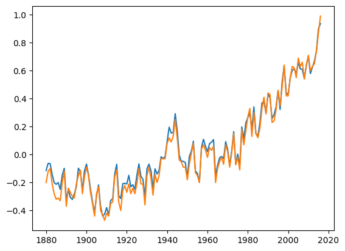

```python
# para que los graficos se muestren correctamente en el notebook
%matplotlib inline
import pandas as pd
# importamos una nueva libreria, matplotlib y le damos el alias 'plt'
import matplotlib.pyplot as plt

df = pd.read_csv('annual.csv')  # convertimos en df el archivo
fig, ax = plt.subplots()     # creamos una figura y un eje
 # creamos el gráfico de líneas para GCAG particularizando los valores con [df['Source'] == 'GCAG']
ax.plot(df[df['Source'] == 'GCAG']['Year'], df[df['Source'] == 'GCAG']['Mean'])
# lo mismo con [df['Source'] == 'GISTEMP']
ax.plot(df[df['Source'] == 'GISTEMP']['Year'], df[df['Source'] == 'GISTEMP']['Mean'])
plt.show()   # mostramos el grafico
```

#### Ejercicio 11

Con el df anterior, representar en una figura dos gráficos de líneas dependiendo de la fuente (GCAG o GISTEMP) con colores diferentes, leyenda, títulos individuales y un título global

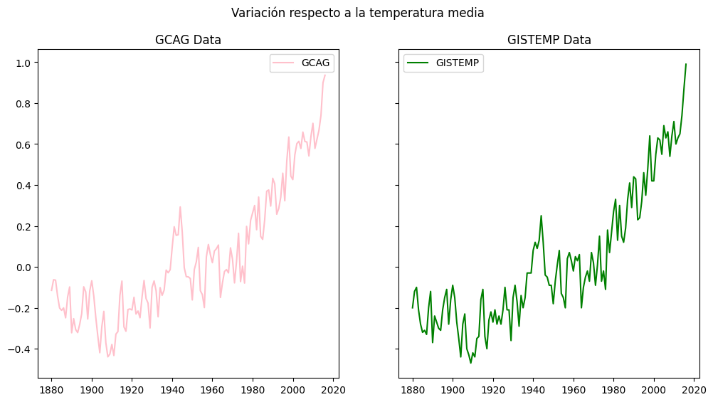

```python
import pandas as pd
import matplotlib.pyplot as plt

df = pd.read_csv('annual.csv')
# creamos una figura compartida con dos figuras en el eje x compartiendo el eje y, con tamaño más grande para visualizarlo correctamente
fig, ax = plt.subplots(1, 2, sharey = True, figsize = (12,6))
# creamos el gráfico de líneas para GCAG particularizando los valores con [df['Source'] == 'GCAG']
ax[0].plot(df[df['Source'] == 'GCAG']['Year'], df[df['Source'] == 'GCAG']['Mean'], label= 'GCAG', color = 'pink')
ax[0].set_title('GCAG Data')     # Añadimos un título para GCAG
ax[0].legend()                   # Añadimos leyenda para GCAG, coge el texto del parámetro label del plot dos líneas más arriba
# lo mismo con [df['Source'] == 'GISTEMP']
ax[1].plot(df[df['Source'] == 'GISTEMP']['Year'], df[df['Source'] == 'GISTEMP']['Mean'], label = 'GISTEMP', color = 'green')
ax[1].set_title('GISTEMP Data')  # Añadimos un título para GISTEMP
ax[1].legend()                   # Añadimos leyenda para GISTEMP
fig.suptitle('Variación respecto a la temperatura media')   # añadimos un título a la figura
plt.show()   # mostramos el grafico
```

#### Ejercicio 12

A partir del archivo company_sales.csv crear un df y representar en un único gráfico multilíneas las ventas de cada producto según el mes.

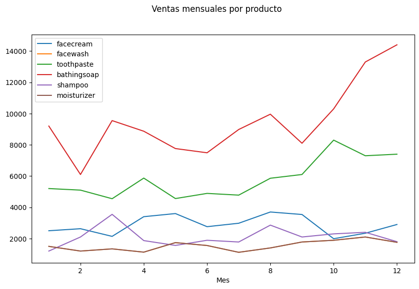

```python
import pandas as pd
import matplotlib.pyplot as plt

df = pd.read_csv('company_sales.csv')
# creamos una figura con tamaño más grande para visualizarlo correctamente
fig, ax = plt.subplots(figsize = (10,6))
# creamos una lista con las columnas que queremos graficar
lista_productos = ['facecream','facewash','toothpaste','bathingsoap','shampoo','moisturizer']
# con un bucle recorremoos la lista
for producto in lista_productos:
    # y representamos la columna producto respecto a la columna mes
    ax.plot(df['month_number'], df[producto], label = producto)
# OPCIONAL
ax.legend()                                    # podemos poner una leyenda
ax.set_xlabel('Mes')                           # un nombre al eje x
fig.suptitle('Ventas mensuales por producto')  # y un titulo

plt.show()
```

#### Ejercicio 13

Utilizando la librería tkinter y etiquetas de texto dibujar el resultado final de una partida de 3 en raya (X y O) en una ventana con un grid de 3x3.

```python
import tkinter as tk                     # importamos la libreria tkinter con el alias tk
window = tk.Tk()                         # creamos un objeto del tipo ventana
window.title("Partida de tres en raya")  # le damos un titulo a la venta
window.geometry('200x200')               # y un tamaño fijo
# lista de listas (matriz 3x3) con el resultado
resultado = [['X','O','X'],['O','X','O'],['X','O','X']]
# utilizamos un bucle anidado para recorrer la matriz
for i in range(3):
    for j in range(3):
        # creamos una etiqueta de texto para cada elemento de la matriz
        lbl = tk.Label(window, text=resultado[i][j])
        # y le asignamos su posicion en la rejilla con margen en x r y
        lbl.grid(column=i, row=j, padx=20, pady=20)

window.mainloop()
```

#### Ejercicio 14

```python
import tkinter as tk
# de la libreria random importamos la funcion randint para generar enteros
from random import randint
window = tk.Tk()
window.title("Número aleatorio")
window.geometry('180x180')
# etiqueta de texto con un valor por defecto
lbl = tk.Label(window, text="NaN", font=("Arial Bold", 18))
lbl.grid(column=0, row=0, padx=10, pady=10)

def clicked():
    # creamos una funcion que modifica la etiqueta de texto con un nuevo numero aleatorio
    lbl.configure(text=randint(1,100))
# creamos un boton con un titulo y le asignamos la funcion clicked como comando
btn = tk.Button(window, text="Generar número aleatorio", command=clicked)
btn.grid(column=0, row=1, padx=10, pady=10)

window.mainloop()
```

#### Ejercicio 15

Crear una ventana con un aviso de estar de que el pc está infectado por un virus y que debe visitar una web inventada y añadir dos botones Aceptar (no hace nada) y Cancelar (cierra la ventana). La ventana tiene que estar organizada de forma convincente, con dimensiones y márgenes.

```python
import tkinter as tk
window = tk.Tk()
window.title("Alerta de seguridad")
window.geometry('370x150')
# etiqueta de texto con un mensaje de virus
lbl = tk.Label(window, text="Su pc está infectado\nvisite www.abcde.com", font=("Arial Bold", 12))
lbl.grid(column=1, row=0, padx=10, pady=10)
# creamos una funcion que cierra la ventana 'window'
def clicked():
    window.destroy()
# creamos un boton con texto sin funcion
btn_aceptar = tk.Button(window, text="Aceptar")
btn_aceptar.grid(column=0, row=1, padx=20, pady=20)
# creamos un boton con texto y le asignamos la funcion clicked como comando
btn_cancelar = tk.Button(window, text="Cancelar", command=clicked)
btn_cancelar.grid(column=2, row=1, padx=20, pady=20)

window.mainloop()
```